# Analysis of World Bank - Bangladesh Informal Firms Survey

**Author:** Milan Patel (Converted to Python)

**Date:** July 12, 2015 (Original), 2025 (Python Conversion)

## Overview

Source of data: [World Bank - Bangladesh Informal Firms Surveys 2010](http://microdata.worldbank.org/index.php/catalog/2244/related_materials)

The World Bank conducted a survey of informal firms in Bangladesh in 2010. An informal firm is a business not registered with the authorities, as opposed to a formal business which is registered with the government, and therefore is subject to a larger degree of legal scrutiny and regulation. Informal businesses often predominate the economy in developing countries, and often are informal due to the high cost of obtaining any sort of formal recognition from the government in terms of time and money, particularly relative to the low or nonexistent benefit of being registered; business registration might end up being even more costly than remaining informal due to the requirement of having to then pay taxes.

The survey asked informal business owners a series of questions covering topics ranging from business characteristics to market conditions. Surveys were conducted in a select number of districts around Bangladesh. Each record of the data indicates one business for which a survey is conducted, and includes district-level geography information (the second level administrative boundary after divisions). Geographic boundary data for Bangladesh sourced via humanitarianresponse.info from World Food Programme.

My analysis intends to explore various characteristics of firms in Bangladesh; specifically, I analyze how annual revenue relates to other variable, such as number of employees, industry sector, financing sources, and geography.

The data set contains a long list of variables from which to compare, and part of the challenge of this project is to select which variables are the most useful to bring out the story of the data. In the visualizations below, the primary dependent variable that I use is Annual Revenue for the year 2009, denominated in Bangladesh Takas, which is the local currency; in 2009, the [exchange rate](http://www.exchange-rates.org/Rate/USD/BDT/12-23-2009) was about 68.4126 takas to the US dollar. The variable is referenced in the exploratory visualizations as "q4_7", which is the variable name. Another often used variable is the number of employees of the firm, which in the exploratory visualizations is referred to as "q1_12a5a".

I should also note that I augmented the data significantly, by linking the survey data (which includes a variable for ISIC code--ISIC being an industry classification system) with ISIC section category descriptions to allow for grouping of responses by industry sector.

```python
# Import required libraries
import pandas as pd
import numpy as np
import matplotlib.pyplot as plt
import seaborn as sns
import geopandas as gpd
from matplotlib.ticker import FuncFormatter
import warnings
from scipy import stats
import plotly.express as px
import plotly.graph_objects as go
from plotly.subplots import make_subplots

# Set style and options
plt.style.use('default')
sns.set_palette("husl")
warnings.filterwarnings('ignore')
pd.set_option('display.max_columns', None)
plt.rcParams['figure.figsize'] = (12, 8)

# Format numbers with commas
def format_thousands(x, pos):
    return f'{x:,.0f}'

formatter = FuncFormatter(format_thousands)
```

```python
# Load survey data
surveydata = pd.read_csv('../data/raw/informality_data_NEW.csv')

print(f"Survey data shape: {surveydata.shape}")
print(f"\nFirst few columns: {list(surveydata.columns[:10])}")
print(f"\nBasic info about key variables:")
print(f"Revenue (q4_7) - Non-null count: {surveydata['q4_7'].notna().sum()}")
print(f"Employees (q1_12a5a) - Non-null count: {surveydata['q1_12a5a'].notna().sum()}")
print(f"District info: {surveydata['dist'].nunique()} unique districts")
```

```
Survey data shape: (1724, 331)

First few columns: ['slno', 'or', 'nob', 'gnd', 'dist', 'q1_1', 's1_1_others', 'q1_2', 'q1_3a', 'q1_3b']

Basic info about key variables:
Revenue (q4_7) - Non-null count: 1724
Employees (q1_12a5a) - Non-null count: 1724
District info: 19 unique districts
```

# Analysis

## A Geographic Overview of Bangladesh

```python
# Load geographic shapefile data
districtmap = gpd.read_file('../data/spatial/bangladesh_districts/bgd_polbnda_adm2_wfp.shp')

# Prepare map data - convert district names to uppercase for matching
districtmap['ADM2_NAME_UPPER'] = districtmap['ADM2_NAME'].str.upper()

# Calculate averages by district
aggdata = surveydata.groupby('dist').agg({
    'q4_7': 'mean',  # average revenue
    'q1_12a5a': 'mean',  # average employees
    'slno': 'count'  # count of firms
}).reset_index()

aggdata.columns = ['dist', 'avg_revenue', 'avg_employees', 'firm_count']
aggdata['dist_upper'] = aggdata['dist'].str.upper()

print(f"Districts in survey data: {aggdata['dist'].unique()}")
print(f"Districts in map data: {districtmap['ADM2_NAME'].head(10).values}")

# Merge map and survey data
plot_data = districtmap.merge(aggdata, left_on='ADM2_NAME_UPPER', right_on='dist_upper', how='left')

print(f"Successfully merged districts: {plot_data['avg_revenue'].notna().sum()}")
```

```
Districts in survey data: ['BARISAL' 'BOGRA' 'CHITTAGONG' 'COMILLA' "COX'S BAZAR" 'DHAKA' 'DINAJPUR'
 'FARIDPUR' 'JESSORE' 'KHULNA' 'KUSHTIA' 'MYMENSINGH' 'NOAKHALI' 'PABNA'
 'PATUAKHALI' 'RAJSHAHI' 'RANGPUR' 'SYLHET' 'TANGAIL']
Districts in map data: ['Bagerhat' 'Bandarban' 'Barguna' 'Barisal' 'Bhola' 'Bogra'
 'Brahamanbaria' 'Chandpur' 'Chittagong' 'Chuadanga']
Successfully merged districts: 19
```

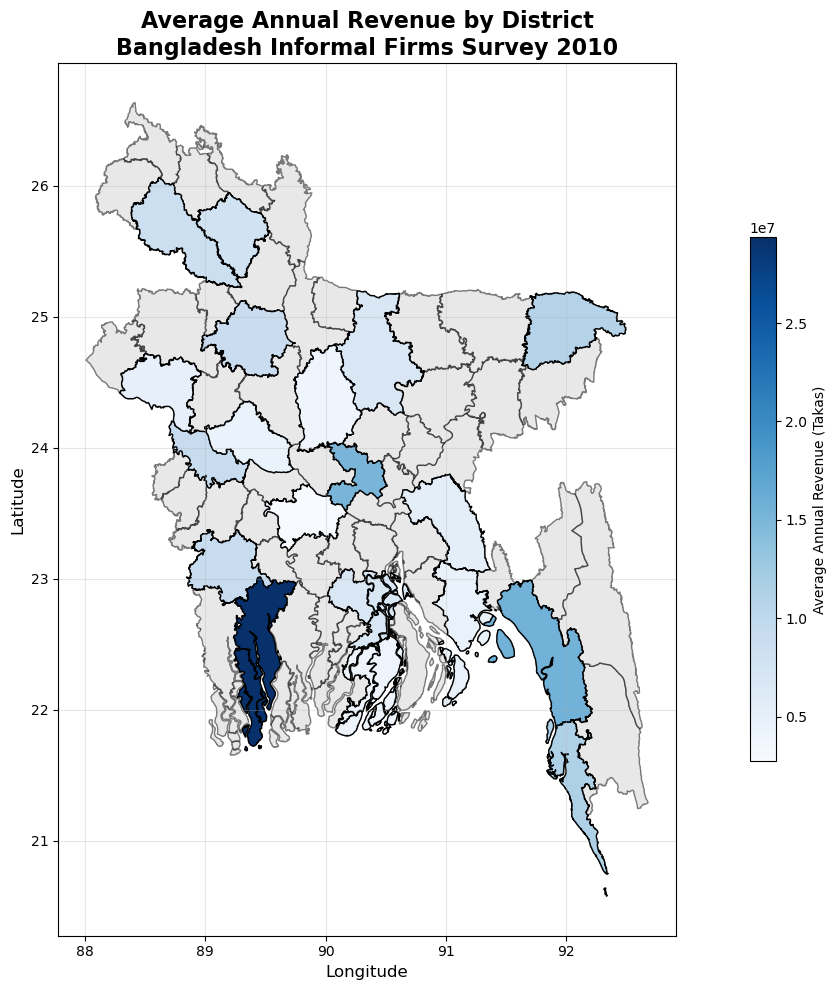

```
Average Revenue by District (Top 5):
           dist  avg_revenue  firm_count
9        KHULNA   29348763.0          87
2    CHITTAGONG   15540284.0         183
5         DHAKA   15112470.0         431
4   COX'S BAZAR   11285790.0          84
17       SYLHET   10867739.0          69
```

```python
# Create geographic plot of average revenue
fig, ax = plt.subplots(1, 1, figsize=(15, 10))

# Plot base map (all districts)
districtmap.plot(ax=ax, color='lightgray', edgecolor='black', alpha=0.5)

# Plot districts with data
plot_data_with_revenue = plot_data.dropna(subset=['avg_revenue'])
plot_data_with_revenue.plot(
    column='avg_revenue',
    ax=ax,
    legend=True,
    cmap='Blues',
    edgecolor='black',
    legend_kwds={'label': 'Average Annual Revenue (Takas)',
                'orientation': 'vertical', 'shrink': 0.6}
)

ax.set_title('Average Annual Revenue by District\nBangladesh Informal Firms Survey 2010',
            fontsize=16, fontweight='bold')
ax.set_xlabel('Longitude', fontsize=12)
ax.set_ylabel('Latitude', fontsize=12)
ax.grid(True, alpha=0.3)

plt.tight_layout()
plt.show()

# Show summary statistics
print("\nAverage Revenue by District (Top 5):")
print(aggdata.nlargest(5, 'avg_revenue')[['dist', 'avg_revenue', 'firm_count']].round(0))
```

The figure above shows Average Revenue, denominated in local currency (Takas), in the year 2009 for businesses in the surveyed districts. A few things are made apparent on this plot. First of all, the survey was conducted only in a selection of districts, not the whole country, and only the surveyed districts are filled with some kind of color.

Now, let's take a closer look at the data for annual revenue.

## Analysis of Annual Revenue Variable

Let's explore the Annual Revenue variable through a series of histograms.

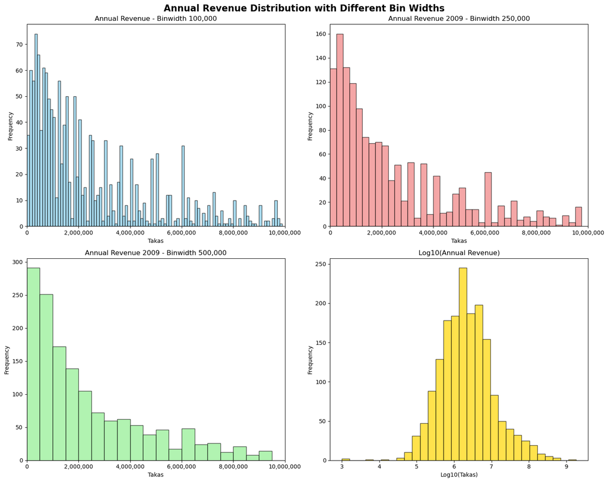

```
Revenue statistics:
Mean: 11,130,553
Median: 2,000,000
Std: 56,437,836
Min: 999
Max: 1,860,000,000
```

```python
# Create histograms with different bin widths
fig, axes = plt.subplots(2, 2, figsize=(15, 12))
fig.suptitle('Annual Revenue Distribution with Different Bin Widths', fontsize=16, fontweight='bold')

# Remove rows with missing revenue data
revenue_data = surveydata['q4_7'].dropna()

# Histogram 1: binwidth equivalent to 100000
axes[0,0].hist(revenue_data, bins=np.arange(0, 10000000, 100000),
               color='skyblue', alpha=0.7, edgecolor='black')
axes[0,0].set_xlim(0, 10000000)
axes[0,0].set_title('Annual Revenue - Binwidth 100,000')
axes[0,0].set_xlabel('Takas')
axes[0,0].set_ylabel('Frequency')
axes[0,0].xaxis.set_major_formatter(formatter)

# Histogram 2: binwidth equivalent to 250000
axes[0,1].hist(revenue_data, bins=np.arange(0, 10000000, 250000),
               color='lightcoral', alpha=0.7, edgecolor='black')
axes[0,1].set_xlim(0, 10000000)
axes[0,1].set_title('Annual Revenue 2009 - Binwidth 250,000')
axes[0,1].set_xlabel('Takas')
axes[0,1].set_ylabel('Frequency')
axes[0,1].xaxis.set_major_formatter(formatter)

# Histogram 3: binwidth equivalent to 500000
axes[1,0].hist(revenue_data, bins=np.arange(0, 10000000, 500000),
               color='lightgreen', alpha=0.7, edgecolor='black')
axes[1,0].set_xlim(0, 10000000)
axes[1,0].set_title('Annual Revenue 2009 - Binwidth 500,000')
axes[1,0].set_xlabel('Takas')
axes[1,0].set_ylabel('Frequency')
axes[1,0].xaxis.set_major_formatter(formatter)

# Histogram 4: Log transformation
log_revenue = np.log10(revenue_data.replace(0, np.nan).dropna())
axes[1,1].hist(log_revenue, bins=30, color='gold', alpha=0.7, edgecolor='black')
axes[1,1].set_title('Log10(Annual Revenue)')
axes[1,1].set_xlabel('Log10(Takas)')
axes[1,1].set_ylabel('Frequency')

plt.tight_layout()
plt.show()

print(f"Revenue statistics:")
print(f"Mean: {revenue_data.mean():,.0f}")
print(f"Median: {revenue_data.median():,.0f}")
print(f"Std: {revenue_data.std():,.0f}")
print(f"Min: {revenue_data.min():,.0f}")
print(f"Max: {revenue_data.max():,.0f}")
```

What do the differences in binwidth tell us? The histogram with binwidth of 100,000 demonstrates that the data periodically spikes, and does not appear as smooth as the next 2 histograms. These spikes likely result because survey respondents would tend to give estimated answers, corresponding to rounded increments.

The second histogram reduces the number of spikes substantially, and the third almost eliminates them entirely, creating a smooth staircase shape. I believe that the second histogram sufficiently manages the spikes without totally eliminating the variety of responses, so I believe that one is the best to use.

The logarithmic adjustment of the annual revenue variable creates a new histogram that displays the data as a normal distribution.

Let's take another view of business size, by comparing annual revenue to number of employees.

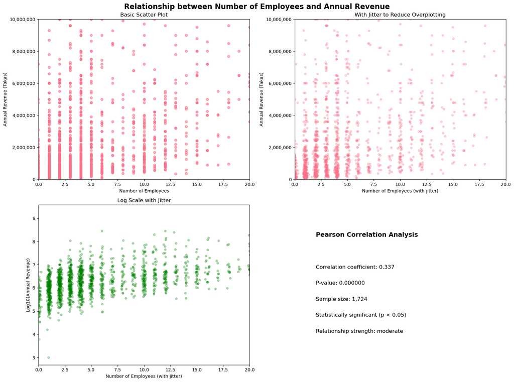

```python
# Employee vs Revenue scatter plots
fig, axes = plt.subplots(2, 2, figsize=(16, 12))
fig.suptitle('Relationship between Number of Employees and Annual Revenue', fontsize=16, fontweight='bold')

# Remove rows with missing data for both variables
clean_data = surveydata.dropna(subset=['q4_7', 'q1_12a5a'])

# Plot 1: Basic scatter plot
axes[0,0].scatter(clean_data['q1_12a5a'], clean_data['q4_7'], alpha=0.6, s=30)
axes[0,0].set_xlim(0, 20)
axes[0,0].set_ylim(0, 10000000)
axes[0,0].set_xlabel('Number of Employees')
axes[0,0].set_ylabel('Annual Revenue (Takas)')
axes[0,0].set_title('Basic Scatter Plot')
axes[0,0].yaxis.set_major_formatter(formatter)

# Plot 2: With jitter (add small random noise to x-axis)
x_jitter = clean_data['q1_12a5a'] + np.random.normal(0, 0.1, len(clean_data))
axes[0,1].scatter(x_jitter, clean_data['q4_7'], alpha=0.3, s=20)
axes[0,1].set_xlim(0, 20)
axes[0,1].set_ylim(0, 10000000)
axes[0,1].set_xlabel('Number of Employees (with jitter)')
axes[0,1].set_ylabel('Annual Revenue (Takas)')
axes[0,1].set_title('With Jitter to Reduce Overplotting')
axes[0,1].yaxis.set_major_formatter(formatter)

# Plot 3: Log scale with jitter
log_revenue_clean = np.log10(clean_data['q4_7'].replace(0, np.nan).dropna())
emp_clean = clean_data.loc[clean_data['q4_7'] > 0, 'q1_12a5a']
x_jitter_log = emp_clean + np.random.normal(0, 0.1, len(emp_clean))

axes[1,0].scatter(x_jitter_log, log_revenue_clean, alpha=0.3, s=20, color='green')
axes[1,0].set_xlim(0, 20)
axes[1,0].set_xlabel('Number of Employees (with jitter)')
axes[1,0].set_ylabel('Log10(Annual Revenue)')
axes[1,0].set_title('Log Scale with Jitter')

# Plot 4: Correlation analysis
axes[1,1].axis('off')
correlation_coeff, p_value = stats.pearsonr(clean_data['q4_7'], clean_data['q1_12a5a'])
axes[1,1].text(0.1, 0.8, f'Pearson Correlation Analysis', fontsize=14, fontweight='bold')
axes[1,1].text(0.1, 0.6, f'Correlation coefficient: {correlation_coeff:.3f}', fontsize=12)
axes[1,1].text(0.1, 0.5, f'P-value: {p_value:.6f}', fontsize=12)
axes[1,1].text(0.1, 0.4, f'Sample size: {len(clean_data):,}', fontsize=12)

if p_value < 0.05:
    significance = "Statistically significant (p < 0.05)"
else:
    significance = "Not statistically significant (p >= 0.05)"
axes[1,1].text(0.1, 0.3, significance, fontsize=12)

# Interpretation
if abs(correlation_coeff) < 0.3:
    strength = "weak"
elif abs(correlation_coeff) < 0.7:
    strength = "moderate"
else:
    strength = "strong"

axes[1,1].text(0.1, 0.2, f'Relationship strength: {strength}', fontsize=12)

plt.tight_layout()
plt.show()
```

The plot above displays number of employees in the firm on the x axis, and annual revenue on the y axis. It is difficult to discern any clear pattern; We appear to have a problem with overplotting, as many of the data points appear to overlap. This probably results from the fact that number of employees is an integer, and is limited on the graph to a value of 20. The jitter helps somewhat to make clear the varied relationship between number of employees and annual revenue.

The application of logarithmic scaling seems to make clearer a positive relationship between annual revenue and number of employees.

The correlation value indicates that there is a relationship between the number of employees and annual revenue, albeit it cannot be characterized as a strong relationship.

## Analysis of Business Classifications

What type of businesses were surveyed, and is it possible to explore some of their characteristics? Perhaps a more insightful question would be, is it possible to determine if annual revenue varies by business sector?

The survey data includes information about the industry classification of the business; the business information is given via the ISIC code, an industry classification system. ISIC is a 4-tiered classification system, with the lower 3 tiers represented by a numeric code, and a corresponding top level represented by a letter. The lowest (and most granular) level is represented by a 4-digit code.

```python
# Load and process ISIC classification data
isicdata = pd.read_csv('../data/raw/ISIC_Rev_3_english_structure.csv')

# Convert ISIC code to factor and create additional classification levels
surveydata['q1_2'] = surveydata['q1_2'].astype(str)
surveydata['ISIC2_code'] = surveydata['q1_2'].str[:2]

# Merge ISIC descriptions with survey data
# Create mapping dictionaries
isic_section_map = dict(zip(isicdata['Code'].astype(str), isicdata['SectionCode']))
isic_section_desc_map = dict(zip(isicdata['Code'].astype(str), isicdata['SectionDesc']))
isic2_desc_map = dict(zip(isicdata['Code'].astype(str), isicdata.get('Desc_short', isicdata['Description'])))
isic4_desc_map = dict(zip(isicdata['Code'].astype(str), isicdata['Description']))

# Apply mappings
surveydata['ISIC_section'] = surveydata['q1_2'].map(isic_section_map)
surveydata['ISIC_sectiondesc'] = surveydata['q1_2'].map(isic_section_desc_map)
surveydata['ISIC2_desc'] = surveydata['ISIC2_code'].map(isic2_desc_map)
surveydata['ISIC4_desc'] = surveydata['q1_2'].map(isic4_desc_map)

print("ISIC Classification Levels:")
print(f"Level 2 (ISIC2_desc): {surveydata['ISIC2_desc'].nunique()} unique categories")
print(f"Level 4 (ISIC4_desc): {surveydata['ISIC4_desc'].nunique()} unique categories")
print(f"Section level: {surveydata['ISIC_sectiondesc'].nunique()} unique categories")
```

```
ISIC Classification Levels:
Level 2 (ISIC2_desc): 3 unique categories
Level 4 (ISIC4_desc): 75 unique categories
Section level: 7 unique categories
```

```python
# Display business counts by classification level
print("\n=== ISIC Level 2 Number of Businesses ===")
isic2_counts = surveydata['ISIC2_desc'].value_counts().head(10)
print(isic2_counts)

print("\n=== ISIC Level 4 Number of Businesses (Top 15) ===")
isic4_counts = surveydata['ISIC4_desc'].value_counts().head(15)
print(isic4_counts)

print("\n=== ISIC Section Level Number of Businesses ===")
section_counts = surveydata['ISIC_sectiondesc'].value_counts()
print(section_counts)
```

```
=== ISIC Level 2 Number of Businesses ===
ISIC2_desc
Communication        18
Land Transport        6
Transport Support     1
Name: count, dtype: int64

=== ISIC Level 4 Number of Businesses (Top 15) ===
ISIC4_desc
Retail sale of textiles, clothing, footwear and leather goods                                 217
Restaurants, bars and canteens                                                                179
Other retail sale in non-specialized stores                                                    99
Manufacture of structural metal products                                                       92
Other retail sale in specialized stores                                                        86
Retail sale of household appliances, articles and equipment                                    83
Manufacture of wearing apparel, except fur apparel                                             82
Retail sale of pharmaceutical and medical goods, cosmetic and toilet articles                  68
Manufacture of furniture                                                                       64
Retail sale of food, beverages and tobacco in specialized stores                               58
Manufacture of jewellery and related articles                                                  48
Wholesale of food, beverages and tobacco                                                       48
Retail sale of hardware, paint and glass                                                       45
Hairdressing and other beauty treatment                                                        41
Wholesale of construction materials, hardware, plumbing and heating equipment and supplies     35
Name: count, dtype: int64

=== ISIC Section Level Number of Businesses ===
ISIC_sectiondesc
Retail & Repair               909
Manufacturing                 481
Hotels and restaurants        180
Other community                65
Real estate                    32
Logistics & Communications     25
Health and social work          2
Name: count, dtype: int64
```

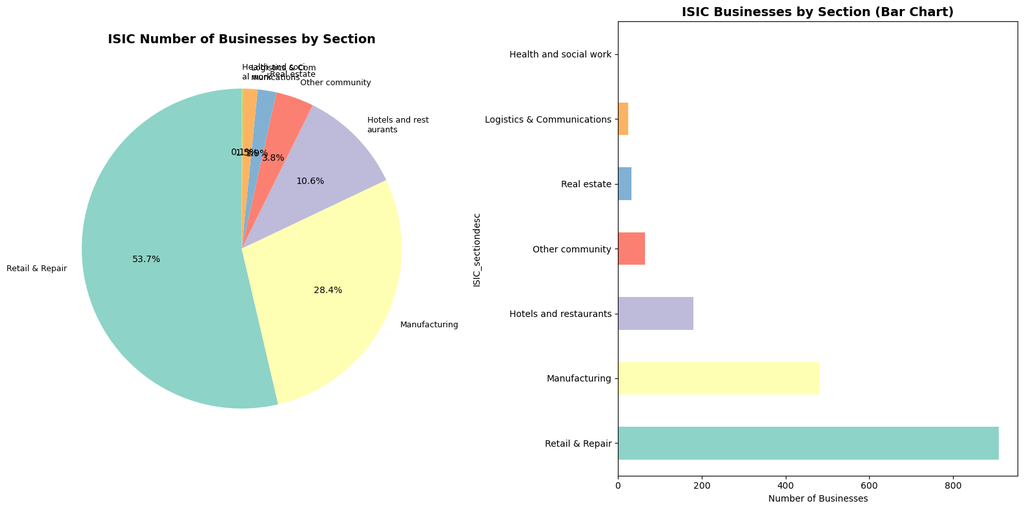

```
The most granular level of classification, Level 4, has 75 distinct values,
while Level 2 has 3 distinct values.
The ISIC Section level has 7 distinct values, which seems ideal for exploration.

As shown in the pie chart, over 50% of businesses are classified under 'Retail and Repair'.
```

```python
# Create pie chart for ISIC sections
fig, (ax1, ax2) = plt.subplots(1, 2, figsize=(16, 8))

# Pie chart
section_counts_clean = surveydata['ISIC_sectiondesc'].dropna().value_counts()
colors = plt.cm.Set3(np.arange(len(section_counts_clean)))

wedges, texts, autotexts = ax1.pie(section_counts_clean.values,
                                  labels=section_counts_clean.index,
                                  autopct='%1.1f%%',
                                  colors=colors,
                                  startangle=90)
ax1.set_title('ISIC Number of Businesses by Section', fontsize=14, fontweight='bold')

# Wrap long labels
for text in texts:
    text.set_fontsize(9)
    wrapped_text = '\n'.join([text.get_text()[i:i+15] for i in range(0, len(text.get_text()), 15)])
    text.set_text(wrapped_text)

# Bar chart for better readability
section_counts_clean.plot(kind='barh', ax=ax2, color=colors)
ax2.set_title('ISIC Businesses by Section (Bar Chart)', fontsize=14, fontweight='bold')
ax2.set_xlabel('Number of Businesses')
ax2.tick_params(axis='y', labelsize=10)

plt.tight_layout()
plt.show()

print(f"\nThe most granular level of classification, Level 4, has {surveydata['ISIC4_desc'].nunique()} distinct values,")
print(f"while Level 2 has {surveydata['ISIC2_desc'].nunique()} distinct values.")
print(f"The ISIC Section level has {surveydata['ISIC_sectiondesc'].nunique()} distinct values, which seems ideal for exploration.")
print(f"\nAs shown in the pie chart, over 50% of businesses are classified under 'Retail and Repair'.")
```

Let's begin by comparing profit levels for the different ISIC sections.

We will first facet annual revenue by ISIC section.

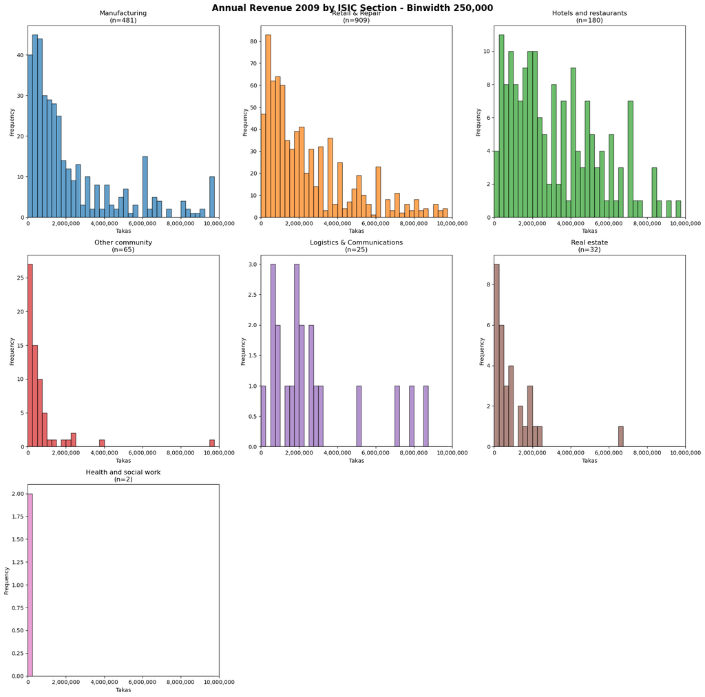

```python
# Faceted histograms by ISIC section
sections_with_data = surveydata.dropna(subset=['ISIC_sectiondesc', 'q4_7'])
unique_sections = sections_with_data['ISIC_sectiondesc'].unique()
n_sections = len(unique_sections)

# Calculate grid dimensions
n_cols = 3
n_rows = (n_sections + n_cols - 1) // n_cols

fig, axes = plt.subplots(n_rows, n_cols, figsize=(18, 6*n_rows))
fig.suptitle('Annual Revenue 2009 by ISIC Section - Binwidth 250,000', fontsize=16, fontweight='bold')

# Flatten axes array for easier indexing
axes = axes.flatten()

for i, section in enumerate(unique_sections):
    if pd.notna(section):
        section_data = sections_with_data[sections_with_data['ISIC_sectiondesc'] == section]['q4_7']

        axes[i].hist(section_data, bins=np.arange(0, 10000000, 250000),
                    color=plt.cm.tab10(i), alpha=0.7, edgecolor='black')
        axes[i].set_xlim(0, 10000000)
        axes[i].set_title(f'{section}\n(n={len(section_data)})', fontsize=12)
        axes[i].set_xlabel('Takas')
        axes[i].set_ylabel('Frequency')
        axes[i].xaxis.set_major_formatter(formatter)

# Hide unused subplots
for j in range(i+1, len(axes)):
    axes[j].set_visible(False)

plt.tight_layout()
plt.show()
```

Let's use box plots to examine the relationship between ISIC sections and revenue.

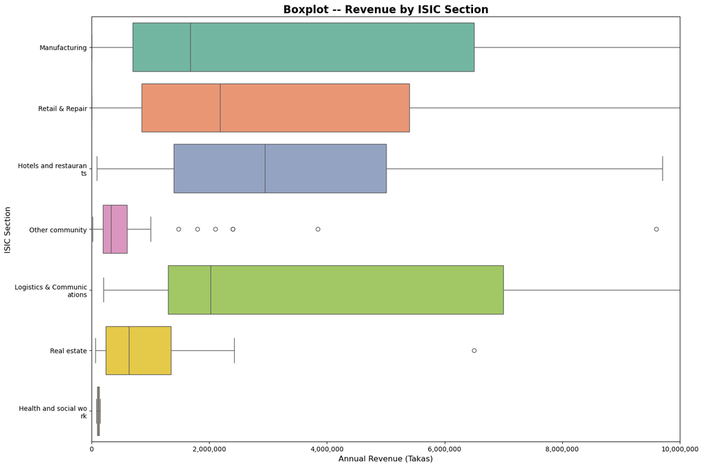

```
=== Revenue Statistics by ISIC Section ===
                            count        mean         std       min  \
ISIC_sectiondesc
Health and social work        2.0    112000.0     45255.0   80000.0
Hotels and restaurants      180.0   4073332.0   4360816.0   90000.0
Logistics & Communications   25.0   5711040.0   9310332.0  200000.0
Manufacturing               481.0  19299894.0  97066514.0     999.0
Other community              65.0    670338.0   1307207.0   16000.0
Real estate                  32.0   1282688.0   2235339.0   60000.0
Retail & Repair             909.0   9384055.0  31220530.0     999.0

                                  25%        50%        75%           max
ISIC_sectiondesc
Health and social work        96000.0   112000.0   128000.0  1.440000e+05
Hotels and restaurants      1400000.0  2947500.0  5010000.0  2.800000e+07
Logistics & Communications  1300000.0  2020000.0  7000000.0  4.440000e+07
Manufacturing                700000.0  1680000.0  6500000.0  1.860000e+09
Other community              190000.0   330000.0   600000.0  9.600000e+06
Real estate                  240000.0   635000.0  1350000.0  1.160000e+07
Retail & Repair              850000.0  2184000.0  5400000.0  6.000000e+08
```

```python
# Box plot of revenue by ISIC section
plt.figure(figsize=(15, 10))

# Filter out missing section descriptions
plot_data = surveydata.dropna(subset=['ISIC_sectiondesc', 'q4_7'])

# Create box plot
box_plot = sns.boxplot(data=plot_data, y='ISIC_sectiondesc', x='q4_7',
                      palette='Set2', orient='h')

# Set limits and formatting
plt.xlim(0, 10000000)
plt.xlabel('Annual Revenue (Takas)', fontsize=12)
plt.ylabel('ISIC Section', fontsize=12)
plt.title('Boxplot -- Revenue by ISIC Section', fontsize=16, fontweight='bold')

# Format x-axis labels
plt.gca().xaxis.set_major_formatter(formatter)

# Wrap y-axis labels
labels = [label.get_text() for label in plt.gca().get_yticklabels()]
wrapped_labels = ['\n'.join([label[i:i+20] for i in range(0, len(label), 20)]) for label in labels]
plt.gca().set_yticklabels(wrapped_labels, fontsize=10)

plt.tight_layout()
plt.show()

# Calculate summary statistics by section
print("\n=== Revenue Statistics by ISIC Section ===")
summary_stats = plot_data.groupby('ISIC_sectiondesc')['q4_7'].describe()
print(summary_stats.round(0))
```

# Part 2: Business Size Analysis and Financing Sources

## Exploring Business Size - Revenue vs Number of Employees

As another measure of business size, how does the number of employees vary across ISIC sections?

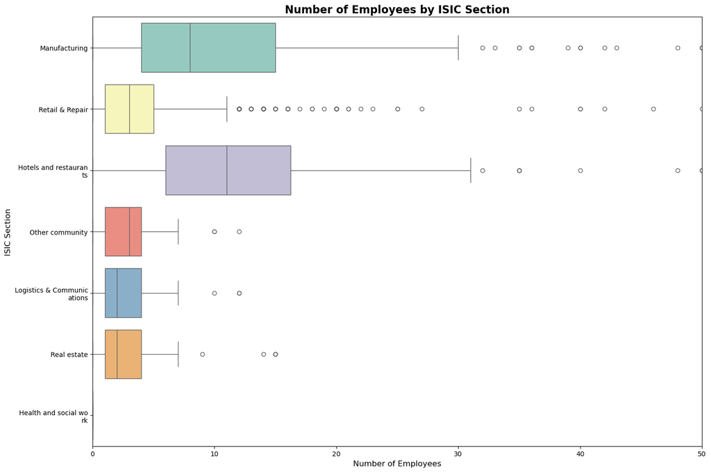

```python
# Box plot of number of employees by ISIC section
plt.figure(figsize=(15, 10))

# Filter data
emp_data = surveydata.dropna(subset=['ISIC_sectiondesc', 'q1_12a5a'])
emp_data = emp_data[emp_data['ISIC_sectiondesc'] != '']

# Create box plot
sns.boxplot(data=emp_data, y='ISIC_sectiondesc', x='q1_12a5a',
           palette='Set3', orient='h')

plt.xlim(0, 50)
plt.xlabel('Number of Employees', fontsize=12)
plt.ylabel('ISIC Section', fontsize=12)
plt.title('Number of Employees by ISIC Section', fontsize=16, fontweight='bold')

# Wrap y-axis labels
labels = [label.get_text() for label in plt.gca().get_yticklabels()]
wrapped_labels = ['\n'.join([label[i:i+20] for i in range(0, len(label), 20)]) for label in labels]
plt.gca().set_yticklabels(wrapped_labels, fontsize=10)

plt.tight_layout()
plt.show()
```

Based on this boxplot, section Hotels & Restaurants has the highest median number of employees, followed by Manufacturing. The medians for those sections are significantly higher than the other sections, and the difference between 1st and 3rd quartiles wider.

### Point Plot comparison - Annual Revenue & Number of Employees by ISIC section

Now, let's explore the two size characteristics together with the ISIC section, all on the same point plot.

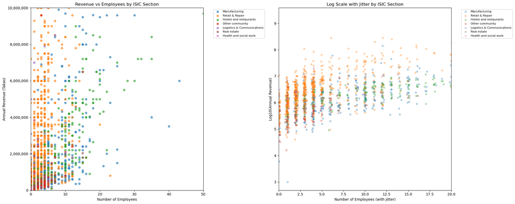

```python
# Scatter plots with ISIC sections colored
fig, (ax1, ax2) = plt.subplots(1, 2, figsize=(20, 8))

# Prepare data
scatter_data = surveydata.dropna(subset=['q4_7', 'q1_12a5a', 'ISIC_sectiondesc'])
scatter_data = scatter_data[scatter_data['ISIC_sectiondesc'] != '']

# Plot 1: Regular scale
for i, section in enumerate(scatter_data['ISIC_sectiondesc'].unique()):
    section_data = scatter_data[scatter_data['ISIC_sectiondesc'] == section]
    ax1.scatter(section_data['q1_12a5a'], section_data['q4_7'],
               label=section, alpha=0.6, s=30, color=plt.cm.tab10(i))

ax1.set_xlim(0, 50)
ax1.set_ylim(0, 10000000)
ax1.set_xlabel('Number of Employees')
ax1.set_ylabel('Annual Revenue (Takas)')
ax1.set_title('Revenue vs Employees by ISIC Section')
ax1.yaxis.set_major_formatter(formatter)
ax1.legend(bbox_to_anchor=(1.05, 1), loc='upper left', fontsize=8)

# Plot 2: Log scale with jitter
for i, section in enumerate(scatter_data['ISIC_sectiondesc'].unique()):
    section_data = scatter_data[scatter_data['ISIC_sectiondesc'] == section]
    # Remove zeros for log transformation
    section_data_pos = section_data[section_data['q4_7'] > 0]
    if len(section_data_pos) > 0:
        # Add jitter to x-axis
        x_jitter = section_data_pos['q1_12a5a'] + np.random.normal(0, 0.1, len(section_data_pos))
        ax2.scatter(x_jitter, np.log10(section_data_pos['q4_7']),
                   label=section, alpha=0.3, s=20, color=plt.cm.tab10(i))

ax2.set_xlim(0, 20)
ax2.set_xlabel('Number of Employees (with jitter)')
ax2.set_ylabel('Log10(Annual Revenue)')
ax2.set_title('Log Scale with Jitter by ISIC Section')
ax2.legend(bbox_to_anchor=(1.05, 1), loc='upper left', fontsize=8)

plt.tight_layout()
plt.show()
```

What is apparent in the first plot is made more explicit in the second plot (the one with the logarithmic adjustment applied to annual revenue): how intensively different ISIC sections utilise labor. ISIC section Retail & Repair has revenue that grows very quickly for a small growth of number of employees; however, in sectors Hotels & Restaurants and Manufacturing, annual revenue increases more slowly as number of employees grow--implying that those sectors are more dependent on labor for growth.

Let's explore the correlation between revenue and number of employees by section.

```
=== Correlation Analysis: Annual Revenue vs Number of Employees by ISIC Section ===

**Manufacturing** (ISIC Section D)
  Correlation coefficient: 0.348
  P-value: 0.000000
  Sample size: 481
  Significance: Yes (p < 0.05)

**Retail & Repair** (ISIC Section G)
  Correlation coefficient: 0.378
  P-value: 0.000000
  Sample size: 909
  Significance: Yes (p < 0.05)

**Hotels and restaurants** (ISIC Section H)
  Correlation coefficient: 0.828
  P-value: 0.000000
  Sample size: 180
  Significance: Yes (p < 0.05)

**Other community** (ISIC Section O)
  Correlation coefficient: 0.217
  P-value: 0.082474
  Sample size: 65
  Significance: No (p < 0.05)
```

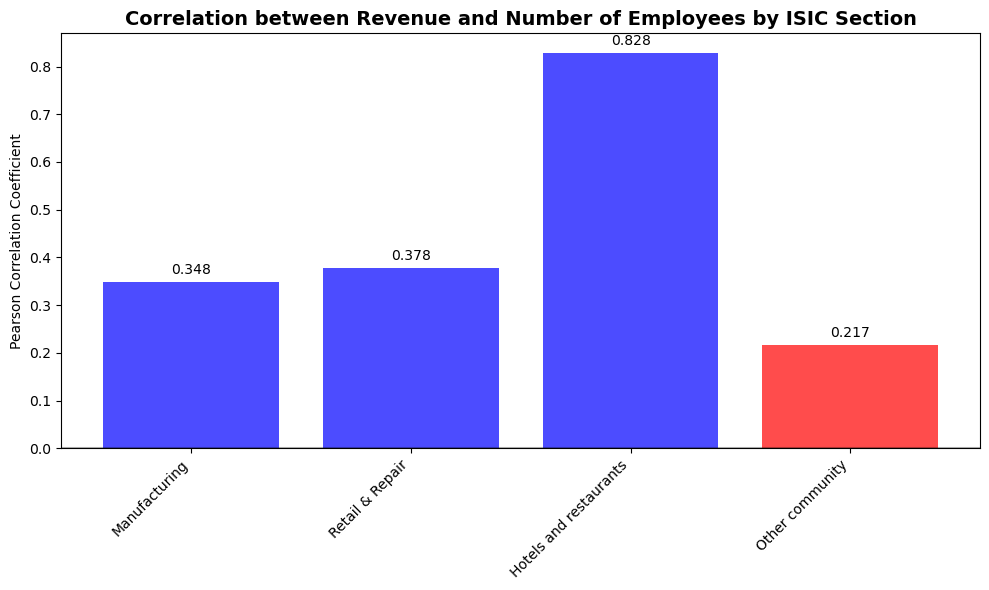

```
Note: Blue bars indicate statistically significant correlations (p < 0.05)
Red bars indicate non-significant correlations (p >= 0.05)
```

```python
# Calculate correlations by ISIC section
sections_to_analyze = ['Manufacturing', 'Retail & Repair', 'Hotels and restaurants', 'Other community']
section_codes = {'Manufacturing': 'D', 'Retail & Repair': 'G',
                'Hotels and restaurants': 'H', 'Other community': 'O'}

correlation_results = {}

print("=== Correlation Analysis: Annual Revenue vs Number of Employees by ISIC Section ===")
print()

for section_name in sections_to_analyze:
    section_code = section_codes.get(section_name)
    if section_code:
        section_data = surveydata[
            (surveydata['ISIC_section'] == section_code) &
            (surveydata['q4_7'].notna()) &
            (surveydata['q1_12a5a'].notna())
        ]

        if len(section_data) > 10:  # Minimum sample size
            corr_coeff, p_value = stats.pearsonr(section_data['q4_7'], section_data['q1_12a5a'])
            correlation_results[section_name] = {'correlation': corr_coeff, 'p_value': p_value, 'n': len(section_data)}

            print(f"**{section_name}** (ISIC Section {section_code})")
            print(f"  Correlation coefficient: {corr_coeff:.3f}")
            print(f"  P-value: {p_value:.6f}")
            print(f"  Sample size: {len(section_data)}")
            print(f"  Significance: {'Yes' if p_value < 0.05 else 'No'} (p < 0.05)")
            print()

# Create visualization of correlations
if correlation_results:
    sections = list(correlation_results.keys())
    correlations = [correlation_results[s]['correlation'] for s in sections]

    plt.figure(figsize=(10, 6))
    bars = plt.bar(sections, correlations,
                  color=['red' if correlation_results[s]['p_value'] >= 0.05 else 'blue' for s in sections],
                  alpha=0.7)

    plt.title('Correlation between Revenue and Number of Employees by ISIC Section',
             fontsize=14, fontweight='bold')
    plt.ylabel('Pearson Correlation Coefficient')
    plt.xticks(rotation=45, ha='right')
    plt.axhline(y=0, color='black', linestyle='-', alpha=0.3)

    # Add correlation values on bars
    for i, (bar, corr) in enumerate(zip(bars, correlations)):
        plt.text(bar.get_x() + bar.get_width()/2, bar.get_height() + 0.01,
                f'{corr:.3f}', ha='center', va='bottom', fontsize=10)

    plt.tight_layout()
    plt.show()

    print("Note: Blue bars indicate statistically significant correlations (p < 0.05)")
    print("Red bars indicate non-significant correlations (p >= 0.05)")
```

One can see that the correlations vary quite widely by industry. In the Manufacturing and Retail & Repair sections, the correlations are substantial, but not particularly strong. The correlation in section Other Community is the weakest of the 4 selected sections. On the other hand, in section "Hotels and Restaurants", the correlation is much higher than the other sections.

## Exploring the sources of financing for businesses

Now, let's explore some of the other characteristics of the business. The dataset contains information about sources of loans. The respondent is asked to give a series of yes/no answers about whether the business takes credit from various types of sources, such as banks or moneylenders. In order to create a plot that can allow us to compare the responses, the data requires some manipulation to achieve the right input format.

```python
# Create financing source analysis
# Map the financing source columns
finance_columns = {
    'q3_5a1': 'Private bank',
    'q3_5a2': 'Government bank',
    'q3_5a3': 'Microfinance Organization',
    'q3_5a4': 'Moneylender',
    'q3_5a5': 'Family and Friends',
    'q3_5a6': 'Other'
}

# Create a long-format dataset for financing sources
finance_data_list = []

for col, source_name in finance_columns.items():
    if col in surveydata.columns:
        temp_df = surveydata[['slno', col, 'q4_7', 'ISIC_sectiondesc']].copy()
        temp_df.columns = ['slno', 'response', 'revenue', 'isic_section']
        temp_df['financesource'] = source_name
        temp_df['response'] = temp_df['response'].astype(str)
        finance_data_list.append(temp_df)

# Combine all financing source data
survey_finc_merged = pd.concat(finance_data_list, ignore_index=True)

# Convert response to proper format (1 = Yes, 2 = No typically)
survey_finc_merged['response_binary'] = survey_finc_merged['response'].map({'1': 'Yes', '2': 'No', '1.0': 'Yes', '2.0': 'No'})
survey_finc_merged = survey_finc_merged.dropna(subset=['response_binary'])

print(f"Finance data shape: {survey_finc_merged.shape}")
print(f"Financing sources: {survey_finc_merged['financesource'].unique()}")
print(f"Response distribution: {survey_finc_merged['response_binary'].value_counts()}")
```

```
Finance data shape: (8629, 6)
Financing sources: ['Private bank' 'Government bank' 'Microfinance Organization'
 'Moneylender' 'Family and Friends' 'Other']
Response distribution: response_binary
No     7105
Yes    1524
Name: count, dtype: int64
```

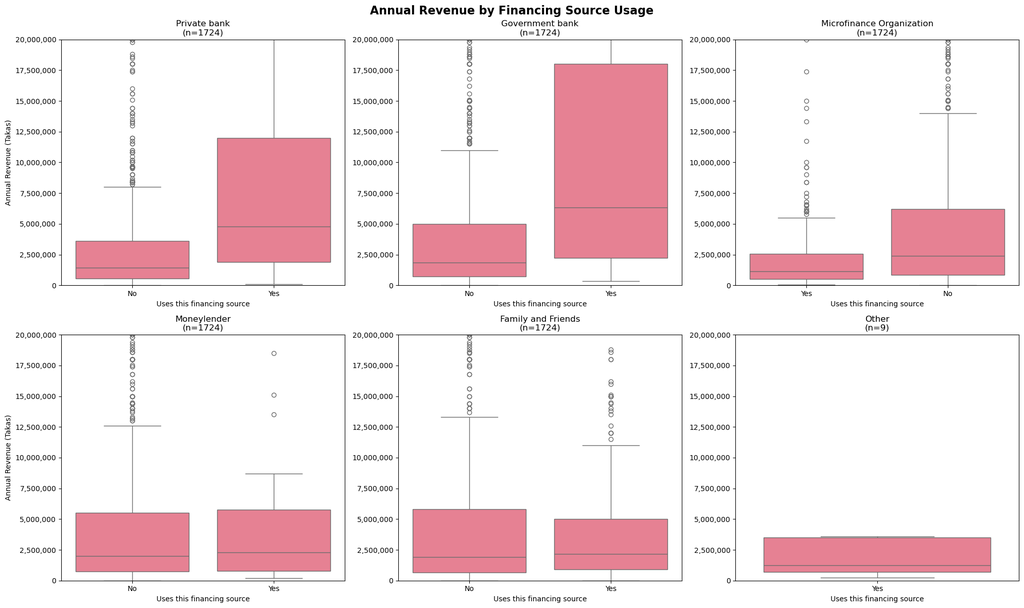

```
=== Summary Statistics for Firms Using Each Financing Source ===

**Private bank** (n=523):
  Median: 4,800,000 Takas
  Mean: 24,914,059 Takas
  Q1: 1,900,000 Takas
  Q3: 12,000,000 Takas

**Government bank** (n=110):
  Median: 6,350,000 Takas
  Mean: 25,401,445 Takas
  Q1: 2,235,000 Takas
  Q3: 18,000,000 Takas

**Microfinance Organization** (n=303):
  Median: 1,146,000 Takas
  Mean: 3,128,318 Takas
  Q1: 500,000 Takas
  Q3: 2,560,000 Takas

**Moneylender** (n=46):
  Median: 2,300,000 Takas
  Mean: 10,261,165 Takas
  Q1: 767,500 Takas
  Q3: 5,750,000 Takas

**Family and Friends** (n=533):
  Median: 2,160,000 Takas
  Mean: 10,276,480 Takas
  Q1: 900,000 Takas
  Q3: 5,000,000 Takas

**Other** (n=9):
  Median: 1,250,000 Takas
  Mean: 13,721,111 Takas
  Q1: 720,000 Takas
  Q3: 3,500,000 Takas
```

```python
# Create faceted boxplots for financing sources
fig, axes = plt.subplots(2, 3, figsize=(20, 12))
fig.suptitle('Annual Revenue by Financing Source Usage', fontsize=16, fontweight='bold')

axes = axes.flatten()
finance_sources = survey_finc_merged['financesource'].unique()

for i, source in enumerate(finance_sources):
    if i < len(axes):
        source_data = survey_finc_merged[
            (survey_finc_merged['financesource'] == source) &
            (survey_finc_merged['revenue'].notna())
        ]

        if len(source_data) > 0:
            sns.boxplot(data=source_data, x='response_binary', y='revenue', ax=axes[i])
            axes[i].set_ylim(0, 20000000)
            axes[i].set_title(f'{source}\n(n={len(source_data)})')
            axes[i].set_xlabel('Uses this financing source')
            axes[i].set_ylabel('Annual Revenue (Takas)' if i % 3 == 0 else '')
            axes[i].yaxis.set_major_formatter(formatter)
        else:
            axes[i].set_visible(False)

# Hide unused subplots
for j in range(len(finance_sources), len(axes)):
    axes[j].set_visible(False)

plt.tight_layout()
plt.show()

# Summary statistics for firms that use each financing source
print("\n=== Summary Statistics for Firms Using Each Financing Source ===")
for source in finance_sources:
    yes_data = survey_finc_merged[
        (survey_finc_merged['financesource'] == source) &
        (survey_finc_merged['response_binary'] == 'Yes') &
        (survey_finc_merged['revenue'].notna())
    ]['revenue']

    if len(yes_data) > 0:
        print(f"\n**{source}** (n={len(yes_data)}):")
        print(f"  Median: {yes_data.median():,.0f} Takas")
        print(f"  Mean: {yes_data.mean():,.0f} Takas")
        print(f"  Q1: {yes_data.quantile(0.25):,.0f} Takas")
        print(f"  Q3: {yes_data.quantile(0.75):,.0f} Takas")
```

## Does the lending vary by sector?

Let's look at how the different categories of lenders lend in different sectors.

```
=== GOVERNMENT BANK LENDING BY SECTOR ===
```

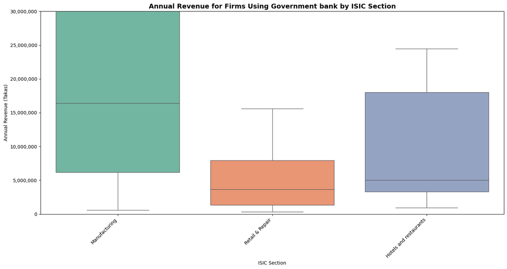

```
                        Count      Median        Mean         Q1          Q3
isic_section
Hotels and restaurants      9   5000000.0  10012989.0  3300000.0  18000000.0
Manufacturing              42  16400000.0  46637390.0  6200000.0  42750000.0
Retail & Repair            58   3665000.0  12766752.0  1350000.0   7950000.0

=== MONEYLENDER LENDING BY SECTOR ===
```

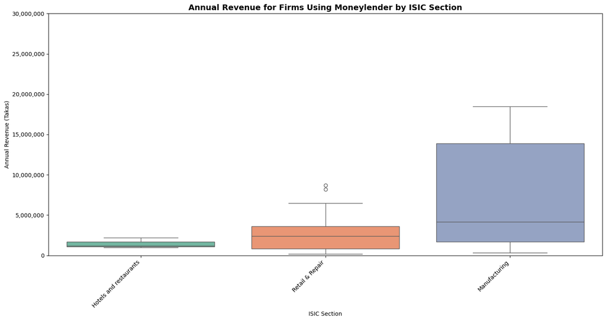

```
                        Count     Median        Mean         Q1          Q3
isic_section
Hotels and restaurants      3  1200000.0   1466667.0  1100000.0   1700000.0
Manufacturing              16  4150000.0  16803600.0  1700000.0  13901400.0
Retail & Repair            23  2400000.0   8574000.0   855000.0   3600000.0

=== MICROFINANCE ORGANIZATION LENDING BY SECTOR ===
```

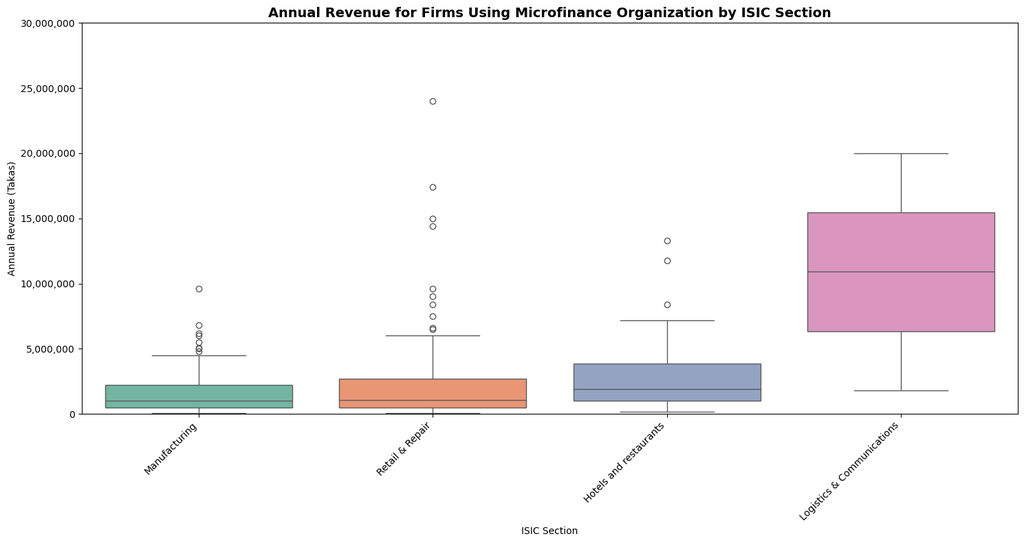

```
                            Count      Median        Mean         Q1  \
isic_section
Hotels and restaurants         54   1880000.0   2766257.0  1020000.0
Logistics & Communications      2  10900000.0  10900000.0  6350000.0
Manufacturing                  83   1000000.0   3977304.0   500000.0
Retail & Repair               139   1080000.0   3022462.0   500000.0

                                    Q3
isic_section
Hotels and restaurants       3875000.0
Logistics & Communications  15450000.0
Manufacturing                2200000.0
Retail & Repair              2700000.0
```

```python
# Lending by sector analysis - focus on key financing sources
key_finance_sources = ['Government bank', 'Moneylender', 'Microfinance Organization']
key_sectors = ['Manufacturing', 'Retail & Repair', 'Hotels and restaurants', 'Logistics & Communications']

for finance_source in key_finance_sources:
    print(f"\n=== {finance_source.upper()} LENDING BY SECTOR ===")

    # Filter data for this financing source
    source_data = survey_finc_merged[
        (survey_finc_merged['financesource'] == finance_source) &
        (survey_finc_merged['response_binary'] == 'Yes') &
        (survey_finc_merged['revenue'].notna()) &
        (survey_finc_merged['isic_section'].notna()) &
        (survey_finc_merged['isic_section'].isin(key_sectors))
    ]

    if len(source_data) > 0:
        # Create subplot
        plt.figure(figsize=(15, 8))

        # Box plot by sector
        sns.boxplot(data=source_data, x='isic_section', y='revenue',
                   palette='Set2')

        plt.ylim(0, 30000000)
        plt.title(f'Annual Revenue for Firms Using {finance_source} by ISIC Section',
                 fontsize=14, fontweight='bold')
        plt.xlabel('ISIC Section')
        plt.ylabel('Annual Revenue (Takas)')
        plt.xticks(rotation=45, ha='right')
        plt.gca().yaxis.set_major_formatter(formatter)

        plt.tight_layout()
        plt.show()

        # Summary by sector
        sector_summary = source_data.groupby('isic_section')['revenue'].agg([
            'count', 'median', 'mean', lambda x: x.quantile(0.25), lambda x: x.quantile(0.75)
        ]).round(0)
        sector_summary.columns = ['Count', 'Median', 'Mean', 'Q1', 'Q3']
        print(sector_summary)
    else:
        print(f"No data available for {finance_source}")
```

# Final Plots and Summary

## Plot One

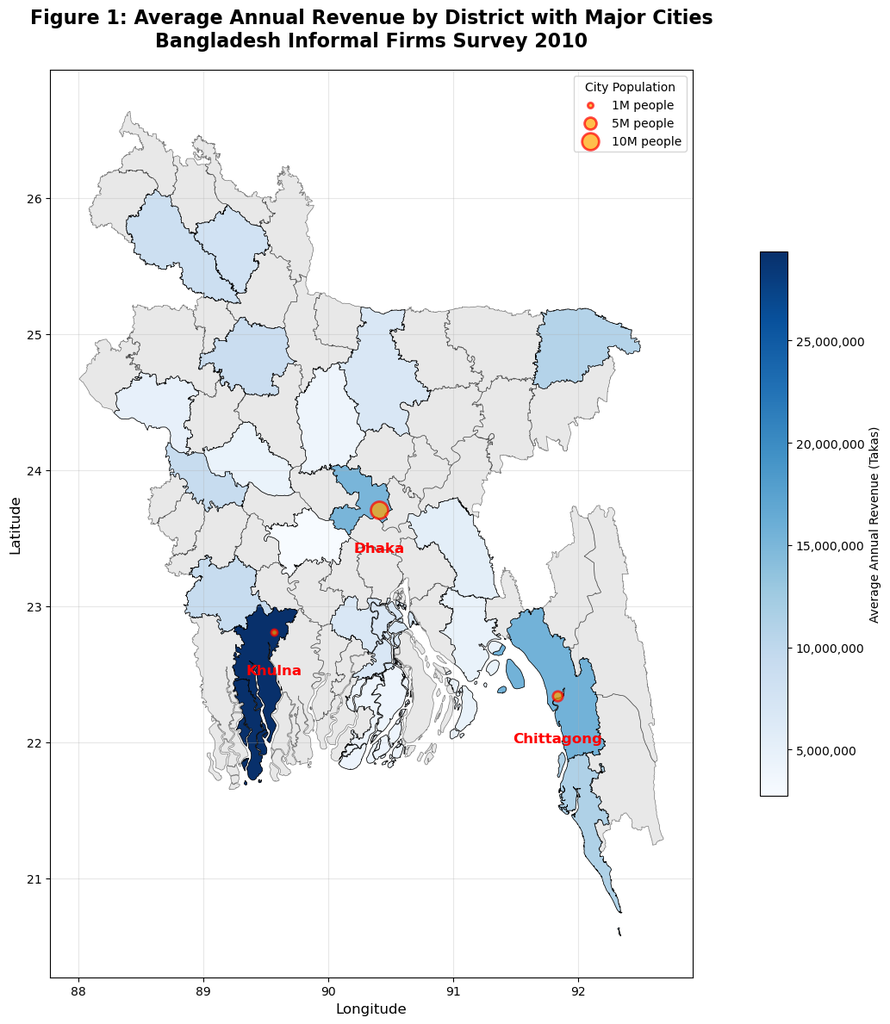

```
=== Geographic Analysis Summary ===
Top 3 districts by average revenue:
  KHULNA: 29,348,763 Takas (n=87)
  CHITTAGONG: 15,540,284 Takas (n=183)
  DHAKA: 15,112,470 Takas (n=431)
```

```python
# Final Plot 1: Enhanced geographic map with major cities
# Major cities data (manually entered based on the original R code)
major_cities = pd.DataFrame({
    'City': ['Dhaka', 'Chittagong', 'Khulna'],
    'Population': [10356500, 3390222, 1342339],
    'Longitude': [90.407, 91.832, 89.564],
    'Latitude': [23.71, 22.338, 22.81],
    'LatitudeName': [23.4, 22, 22.5]  # For label positioning
})

# Load geographic data again
districtmap = gpd.read_file('../data/spatial/bangladesh_districts/bgd_polbnda_adm2_wfp.shp')
districtmap['ADM2_NAME_UPPER'] = districtmap['ADM2_NAME'].str.upper()

# Calculate averages by district
aggdata = surveydata.groupby('dist').agg({
    'q4_7': 'mean',
    'slno': 'count'
}).reset_index()
aggdata.columns = ['dist', 'avg_revenue', 'firm_count']
aggdata['dist_upper'] = aggdata['dist'].str.upper()

# Merge data
plot_data = districtmap.merge(aggdata, left_on='ADM2_NAME_UPPER', right_on='dist_upper', how='left')

# Create the enhanced map
fig, ax = plt.subplots(1, 1, figsize=(16, 12))

# Base map
districtmap.plot(ax=ax, color='lightgray', edgecolor='black', alpha=0.5, linewidth=0.5)

# Revenue data
plot_data_with_revenue = plot_data.dropna(subset=['avg_revenue'])
plot_data_with_revenue.plot(
    column='avg_revenue',
    ax=ax,
    legend=True,
    cmap='Blues',
    edgecolor='black',
    linewidth=0.5,
    legend_kwds={
        'label': 'Average Annual Revenue (Takas)',
        'orientation': 'vertical',
        'shrink': 0.6,
        'format': formatter
    }
)

# Add major cities
# Cities as circles scaled by population
for _, city in major_cities.iterrows():
    ax.scatter(city['Longitude'], city['Latitude'],
              s=city['Population']/50000,  # Scale factor for visibility
              color='orange', alpha=0.7, edgecolor='red', linewidth=2)

# City labels
for _, city in major_cities.iterrows():
    ax.annotate(city['City'],
               xy=(city['Longitude'], city['LatitudeName']),
               fontsize=12, fontweight='bold', color='red',
               ha='center')

ax.set_title('Figure 1: Average Annual Revenue by District with Major Cities\nBangladesh Informal Firms Survey 2010',
            fontsize=16, fontweight='bold', pad=20)
ax.set_xlabel('Longitude', fontsize=12)
ax.set_ylabel('Latitude', fontsize=12)
ax.grid(True, alpha=0.3)

# Add legend for city sizes
sizes = [1000000, 5000000, 10000000]
labels = ['1M', '5M', '10M']
legend_elements = []
for size, label in zip(sizes, labels):
    legend_elements.append(plt.scatter([], [], s=size/50000, color='orange',
                                     alpha=0.7, edgecolor='red', linewidth=2, label=f'{label} people'))

ax.legend(handles=legend_elements, title='City Population', loc='upper right')

plt.tight_layout()
plt.show()

print("\n=== Geographic Analysis Summary ===")
print("Top 3 districts by average revenue:")
top_districts = aggdata.nlargest(3, 'avg_revenue')[['dist', 'avg_revenue', 'firm_count']]
for _, row in top_districts.iterrows():
    print(f"  {row['dist']}: {row['avg_revenue']:,.0f} Takas (n={row['firm_count']})")
```

### Description One

My first final plot is the map of Bangladesh that we used near the beginning of this project, adding some features to provide some context. First of all, I plotted on the map the 3 largest cities in Bangladesh, with orange circles indicating population size of each. As wealth often concentrates in urban areas (typically being centers of economic activity), I wanted to test the idea that firms with the largest level of revenue coincided with major urban centers in Bangladesh. In fact, in this case, we note that the highest average revenue coincides with the three major urban centers; Khulna district has the highest average revenue, and also contains the city of Khulna, the 3rd largest in Bangladesh. Chittagong district, with high average revenue, also contains the second-largest city in Bangladesh. And Dhaka district, where the capital and largest city of Bangladesh is located, also shows high revenue levels.

So, it seems that urbanization in Bangladesh coincides with high annual revenue for firms in those urban locations.

## Plot Two

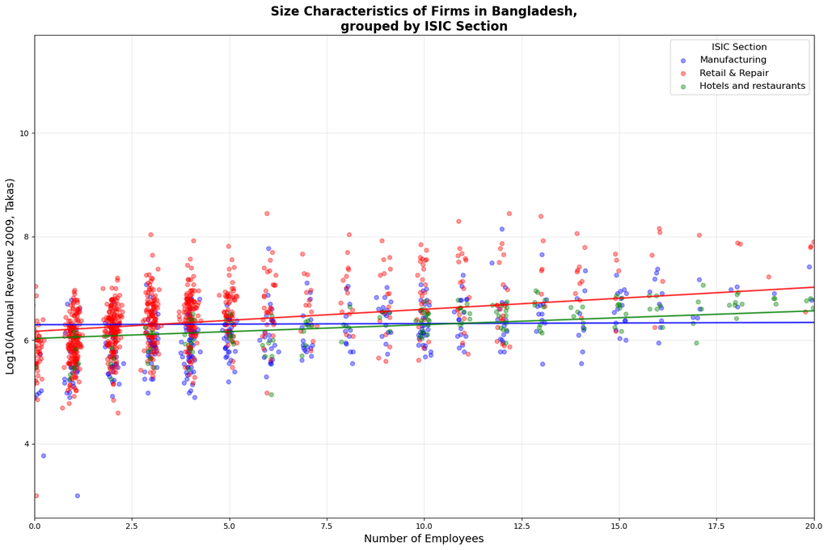

```
=== Trend Line Analysis ===
Manufacturing:
  Slope: 0.0022 (log revenue increase per employee)
  R-squared: 0.141
  P-value: 0.000000
Retail & Repair:
  Slope: 0.0425 (log revenue increase per employee)
  R-squared: 0.239
  P-value: 0.000000
Hotels and restaurants:
  Slope: 0.0267 (log revenue increase per employee)
  R-squared: 0.508
  P-value: 0.000000
```

```python
# Final Plot 2: Enhanced scatter plot with trend lines
selected_sections = ['Manufacturing', 'Retail & Repair', 'Hotels and restaurants']

# Filter data
plot2_data = surveydata[
    (surveydata['ISIC_sectiondesc'].isin(selected_sections)) &
    (surveydata['q4_7'].notna()) &
    (surveydata['q1_12a5a'].notna()) &
    (surveydata['q4_7'] > 0)  # For log transformation
]

# Create the plot
plt.figure(figsize=(15, 10))

# Color palette for sections
colors = {'Manufacturing': 'blue', 'Retail & Repair': 'red', 'Hotels and restaurants': 'green'}

# Plot points with jitter
for section in selected_sections:
    section_data = plot2_data[plot2_data['ISIC_sectiondesc'] == section]
    if len(section_data) > 0:
        # Add jitter to x-axis
        x_jitter = section_data['q1_12a5a'] + np.random.normal(0, 0.1, len(section_data))
        y_log = np.log10(section_data['q4_7'])

        plt.scatter(x_jitter, y_log, alpha=0.4, s=30,
                   color=colors[section], label=section)

# Add trend lines
for section in selected_sections:
    section_data = plot2_data[plot2_data['ISIC_sectiondesc'] == section]
    if len(section_data) > 10:  # Minimum points for trend line
        x = section_data['q1_12a5a']
        y = np.log10(section_data['q4_7'])

        # Calculate trend line
        z = np.polyfit(x, y, 1)
        p = np.poly1d(z)

        # Plot trend line
        x_trend = np.linspace(x.min(), x.max(), 100)
        plt.plot(x_trend, p(x_trend), color=colors[section], linewidth=2, alpha=0.8)

plt.xlim(0, 20)
plt.xlabel('Number of Employees', fontsize=14)
plt.ylabel('Log10(Annual Revenue 2009, Takas)', fontsize=14)
plt.title('Size Characteristics of Firms in Bangladesh,\ngrouped by ISIC Section',
         fontsize=16, fontweight='bold')
plt.legend(title='ISIC Section', fontsize=12, title_fontsize=12)
plt.grid(True, alpha=0.3)

plt.tight_layout()
plt.show()

# Calculate trend line slopes
print("\n=== Trend Line Analysis ===")
for section in selected_sections:
    section_data = plot2_data[plot2_data['ISIC_sectiondesc'] == section]
    if len(section_data) > 10:
        x = section_data['q1_12a5a']
        y = np.log10(section_data['q4_7'])
        slope, intercept, r_value, p_value, std_err = stats.linregress(x, y)

        print(f"{section}:")
        print(f"  Slope: {slope:.4f} (log revenue increase per employee)")
        print(f"  R-squared: {r_value**2:.3f}")
        print(f"  P-value: {p_value:.6f}")
```

### Description Two

Plot two builds on the point plot comparison above, and refines to add trendlines to the plot. This plot has the following features:

- A log10 scale is applied to the Y axis (Annual Revenue 2009);
- Jitter is applied to avoid overclustering of points;
- The points are colored by ISIC section;
- Trendlines are added for select ISIC sections, to highlight the differences between them.

The trendlines emphasize the findings from the original plot: within the Retail & Repair section, annual revenue increases at a distinctly faster rate as employees increase, than in the Manufacturing and Hotels and restaurants sections. Using the combination of plotting methods, we have been able to identify a differentiating characteristic between certain sectors: at higher levels of revenue, Retail & Repair firms feature fewer employees than the Manufacturing and Hotels & Restaurants sections.

## Plot Three

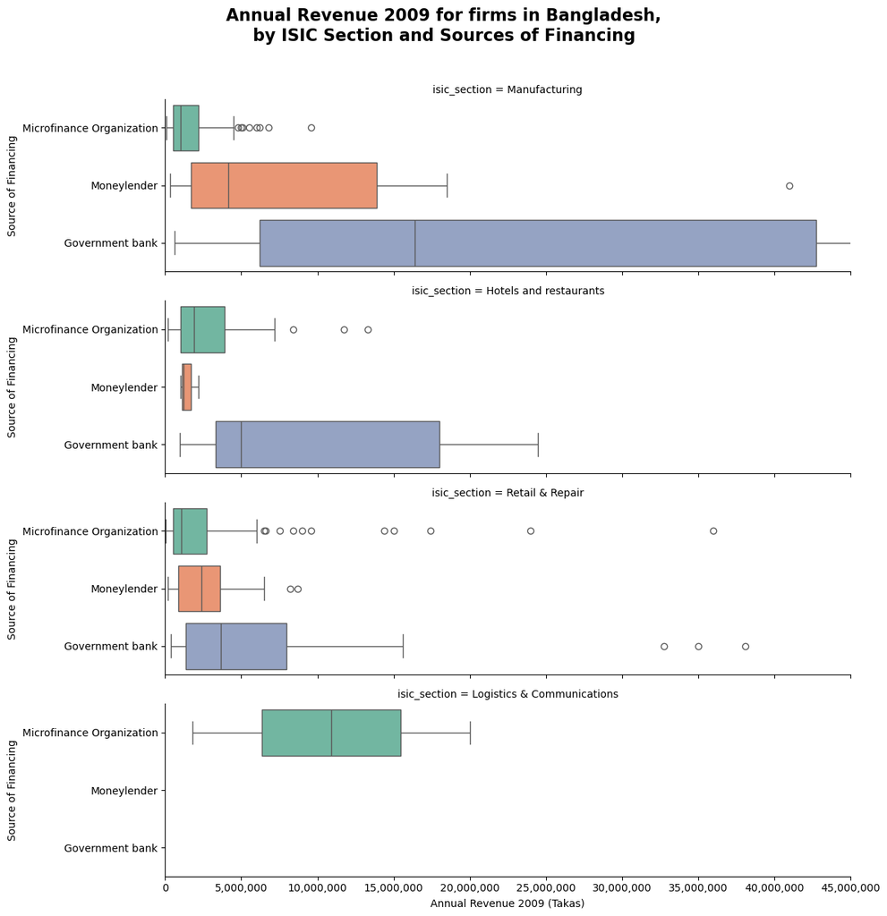

```
=== Summary: Median Revenue by Financing Source and Sector ===
                                                      Count  Median Revenue  \
isic_section               financesource
Manufacturing              Microfinance Organization     83       1000000.0
                           Moneylender                   16       4150000.0
                           Government bank               42      16400000.0
Hotels and restaurants     Microfinance Organization     54       1880000.0
                           Moneylender                    3       1200000.0
                           Government bank                9       5000000.0
Retail & Repair            Microfinance Organization    139       1080000.0
                           Moneylender                   23       2400000.0
                           Government bank               58       3665000.0
Logistics & Communications Microfinance Organization      2      10900000.0
                           Moneylender                    0             NaN
                           Government bank                0             NaN

                                                      Mean Revenue
isic_section               financesource
Manufacturing              Microfinance Organization     3977304.0
                           Moneylender                  16803600.0
                           Government bank              46637390.0
Hotels and restaurants     Microfinance Organization     2766257.0
                           Moneylender                   1466667.0
                           Government bank              10012989.0
Retail & Repair            Microfinance Organization     3022462.0
                           Moneylender                   8574000.0
                           Government bank              12766752.0
Logistics & Communications Microfinance Organization    10900000.0
                           Moneylender                         NaN
                           Government bank                     NaN
```

```python
# Final Plot 3: Comprehensive financing analysis
# Select key financing sources and sectors
selected_finance = ['Microfinance Organization', 'Moneylender', 'Government bank']
selected_sectors = ['Manufacturing', 'Hotels and restaurants', 'Retail & Repair', 'Logistics & Communications']

# Filter and prepare data
plot3_data = survey_finc_merged[
    (survey_finc_merged['financesource'].isin(selected_finance)) &
    (survey_finc_merged['isic_section'].isin(selected_sectors)) &
    (survey_finc_merged['response_binary'] == 'Yes') &
    (survey_finc_merged['revenue'].notna())
]

# Set categorical order for better visualization
plot3_data['financesource'] = pd.Categorical(
    plot3_data['financesource'],
    categories=['Microfinance Organization', 'Moneylender', 'Government bank']
)

plot3_data['isic_section'] = pd.Categorical(
    plot3_data['isic_section'],
    categories=['Manufacturing', 'Hotels and restaurants', 'Retail & Repair', 'Logistics & Communications']
)

# Create the plot
plt.figure(figsize=(16, 12))

# Create horizontal box plot with sectors as separate facets
g = sns.FacetGrid(plot3_data, row='isic_section', height=3, aspect=4,
                  row_order=['Manufacturing', 'Hotels and restaurants', 'Retail & Repair', 'Logistics & Communications'])

g.map_dataframe(sns.boxplot, y='financesource', x='revenue',
               palette='Set2', orient='h')

# Set consistent x-axis limits
for ax in g.axes.flat:
    ax.set_xlim(0, 45000000)
    ax.xaxis.set_major_formatter(formatter)
    ax.set_xlabel('Annual Revenue 2009 (Takas)')
    ax.set_ylabel('Source of Financing')

g.fig.suptitle('Annual Revenue 2009 for firms in Bangladesh,\nby ISIC Section and Sources of Financing',
               fontsize=16, fontweight='bold', y=1.02)

plt.tight_layout()
plt.show()

# Summary statistics table
print("\n=== Summary: Median Revenue by Financing Source and Sector ===")
summary_table = plot3_data.groupby(['isic_section', 'financesource'])['revenue'].agg([
    'count', 'median', 'mean'
]).round(0)
summary_table.columns = ['Count', 'Median Revenue', 'Mean Revenue']
print(summary_table)
```

### Description Three

Plot three is a refinement of the box plots that were explored above. Those box plots informed the creation of plot three in a number of ways.

First, to make an effective and attractive visualization that captures the salient observations of our findings, it would be an idea to limit the number of items within the categories on the plot. For the ISIC section variable, I selected items that have enough observations to be able to draw meaningful insights; we can tell from the box plots and the point plots that items within the ISIC section category, such as "Health & Social Work" and "Other Community" do not have many observations--so it is difficult to glean any insights about those sections. I selected 3 sections: "Hotels and restaurants", "Manufacturing", and "Retail and Repair"--the items that I also highlighted in plot two with trend lines. Also, considering the other categorical variable, Source of Financing, I had noted that the 3 items from ISIC Section had displayed some distinctive characteristics as the source of financing change; additionally, I also included "Logistics and Communications", as for the Source of Financing "Microfinance Organization", the revenue patterns were distinctive when compared to the other ISIC sections.

Second, I noted that when faceting the Source of Financing "Government Banks", it was difficult to create a scale that could adequately show the range of responses for annual revenue; scaling on the y axis that appropriately showed the "Manufacturing" section would distort the plots of the other sections. To resolve this issue, I applied horizontal boxplots.

This plot captures the relevant information that we gathered from the box plots. We can observe that government banks tend to provide credit to firms with higher levels of revenue, while moneylenders and microfinance organizations tend to lend to firms with relatively lower levels of revenue. We can also see the differentiated levels of revenue between the different ISIC sections, with Manufacturing firms having a markedly higher revenue than the other sectors.

Most interestingly, we can observe a potential segmentation of the finance market, by discerning patterns of how different lenders tend to lend to different industries. Microfinance organizations are designed to lend to firms of a very small size--and so one would expect that the firms who receive credit from such sources would have a lower annual revenue. This seems to hold true in most of the sections; however, we can see that firms in Logistics & communications that receive microfinance loans have a median revenue that is much higher than microfinance loan recipients in other sections. Government banks, on the other hand, may tend to target credit towards larger firms--hence the phenomenon of firms in the Manufacturing sector that take government bank loans, that show much higher levels of revenue than in other sections; hence, manufacturers seem to be a good market segment for government banks.

# Reflection

This process has been moderately successful in elucidating some insights about trends in Bangladeshi firms' annual revenue across a number of dimensions, such as geography, number of employees, industry sector, and financing source, with the intention of finding how these various characteristics affect and impact revenue, and more broadly, understand the dynamics of the market in which firms operate in Bangladesh.

My analysis came up with a number of interesting conclusions. First, we observed that annual revenue varied by geography, with the 3 districts having the highest average revenue also containing the 3 largest cities in Bangladesh. This fact supports the hypothesis that there is a positive correlation between urbanization and economic activity. For the purpose of this analysis, the ability to plot this information on a map proved to be essential.

We also have a better understanding of how the two measures of business size in this project (annual revenue and number of employees) were positively correlated, though not strongly so. Our analysis of this relationship was enhanced when we broke down the analysis using the ISIC section variable as an indicator of industry sector, to find that revenue in certain sectors (such as Retail and Repair) had a higher rate of growth as employees increased than in other sectors, such as Manufacturing. Box plots were particularly useful for exploring the ISIC section data; further, viewing the business size data on a point plot, colored by ISIC section, allowed us to see the differentiated trends of business size across industries.

Additionally, we have a better understanding of financing trends. Certain sources of finance, such as government banks, tend to lend to firms with higher revenue, while others, such as microfinance organizations, tend to focus on firms with low revenue. These trends in revenue may mean that sources of financing tend to target certain sectors; government banks lend to a large number of manufacturing firms, as those firms have a high level of revenue. Boxplots were used extensively to arrive at these conclusions.

One major limitation of this analysis was that such insights were limited to only a selection of ISIC sections; this limitation was probably due to the limited availability of observations for ISIC sections beyond those that we examined in depth.

One initial challenge that I had to work through was how to choose a limited set of variables to explore, when so many were available. This also means that there is a lot more data to explore within this data set; the data includes information such as family characteristics and education levels of business owners. Within this data set, I believe there are many other opportunities to segment businesses based on differing characteristics other than the ones we explored here.